# R exercise 1: Know Your Data

# statistics of spread

### variance

```r
var(data$`Life expectancy`, na.rm=TRUE)
```

```
## [1] 90.70405
```

### standard deviation

```r
sd(data$`Life expectancy`, na.rm=TRUE)
```

```
## [1] 9.523867
```

### inter-quartile range

```r
range(data$`Life expectancy`, na.rm=TRUE)
```

```
## [1] 36.3 89.0
```

```r
max(data$`Life expectancy`, na.rm=TRUE)
```

```
## [1] 89
```

```r
min(data$`Life expectancy`, na.rm=TRUE)
```

```
## [1] 36.3
```

```r
IQR(data$`Life expectancy`, na.rm=TRUE)
```

```
## [1] 12.6
```

```r
quantile(data$`Life expectancy`, na.rm=TRUE)
```

```
##   0%  25%  50%  75% 100%
## 36.3 63.1 72.1 75.7 89.0
```

```r
quantile(data$`Life expectancy`, probs=c(0.2, 0.8), na.rm=TRUE)
```

```
##   20%   80%
## 59.90 76.96
```

```r
quantile(data$`Life expectancy`, probs = c(1/3, 2/3), na.rm = TRUE)
```

```
## 33.33333% 66.66667%
##      66.6      74.4
```

# obtain summaries on subset of data

```r
# install.packages("Hmisc")
suppressPackageStartupMessages(library(Hmisc))
describe(data)
```

```
## data
##
##  22  Variables      2938  Observations
## ---------------------------------------------------------------------------
## Country
##        n  missing distinct
##     2938        0      193
##
## lowest : Afghanistan                        Albania                            Algeria                            Angola                             Antigua and Barbuda
## highest: Venezuela (Bolivarian Republic of) Viet Nam                           Yemen                              Zambia                             Zimbabwe
## ---------------------------------------------------------------------------
## Year
##        n  missing distinct     Info     Mean      Gmd      .05      .10
##     2938        0       16    0.996     2008    5.318     2000     2001
##      .25      .50      .75      .90      .95
##     2004     2008     2012     2014     2015
##
## Value       2000  2001  2002  2003  2004  2005  2006  2007  2008  2009
## Frequency    183   183   183   183   183   183   183   183   183   183
## Proportion 0.062 0.062 0.062 0.062 0.062 0.062 0.062 0.062 0.062 0.062
##
## Value       2010  2011  2012  2013  2014  2015
## Frequency    183   183   183   193   183   183
## Proportion 0.062 0.062 0.062 0.066 0.062 0.062
## ---------------------------------------------------------------------------
## Status
##        n  missing distinct
##     2938        0        2
##
## Value       Developed Developing
## Frequency         512       2426
## Proportion      0.174      0.826
## ---------------------------------------------------------------------------
## Life expectancy
##        n  missing distinct     Info     Mean      Gmd      .05      .10
##     2928       10      362        1    69.22    10.62     51.4     54.8
##      .25      .50      .75      .90      .95
##     63.1     72.1     75.7     79.7     82.0
##
## lowest : 36.3 39.0 41.0 41.5 42.3, highest: 85.0 86.0 87.0 88.0 89.0
```

[output cut: 133 more lines]

```
##        n  missing distinct     Info     Mean      Gmd      .05      .10
##     2771      167      625        1   0.6276   0.2271    0.277    0.387
##      .25      .50      .75      .90      .95
##    0.493    0.677    0.779    0.864    0.892
##
## lowest : 0.000 0.253 0.255 0.261 0.266, highest: 0.939 0.941 0.942 0.945 0.948
## ---------------------------------------------------------------------------
## Schooling
##        n  missing distinct     Info     Mean      Gmd      .05      .10
##     2775      163      173        1    11.99    3.713      5.8      7.7
##      .25      .50      .75      .90      .95
##     10.1     12.3     14.3     15.9     16.8
##
## lowest :  0.0  2.8  2.9  3.0  3.1, highest: 20.3 20.4 20.5 20.6 20.7
## ---------------------------------------------------------------------------
```

```r
suppressPackageStartupMessages(library(dplyr))
group_by(data, Country, Status) %>% summarise(nObs=n(), mA7=median(`Life expectancy`))
```

```
## # A tibble: 193 x 4
## # Groups:   Country [193]
##    Country             Status      nObs   mA7
##    <chr>               <chr>      <int> <dbl>
##  1 Afghanistan         Developing    16  57.8
##  2 Albania             Developing    16  75.6
##  3 Algeria             Developing    16  73.9
##  4 Angola              Developing    16  48.4
##  5 Antigua and Barbuda Developing    16  75.1
##  6 Argentina           Developing    16  75.3
##  7 Armenia             Developing    16  73.2
##  8 Australia           Developed     16  81.8
##  9 Austria             Developed     16  81.0
## 10 Azerbaijan          Developing    16  71.4
## # ... with 183 more rows
```

# data visualization: plotting in R

```r
suppressPackageStartupMessages(library(ggplot2))
ggplot(data=data,
       mapping = aes(x = data$`Life expectancy`,
                     y = data$'Year')) +
geom_jitter()+
  xlab ('Life expectancy')
```

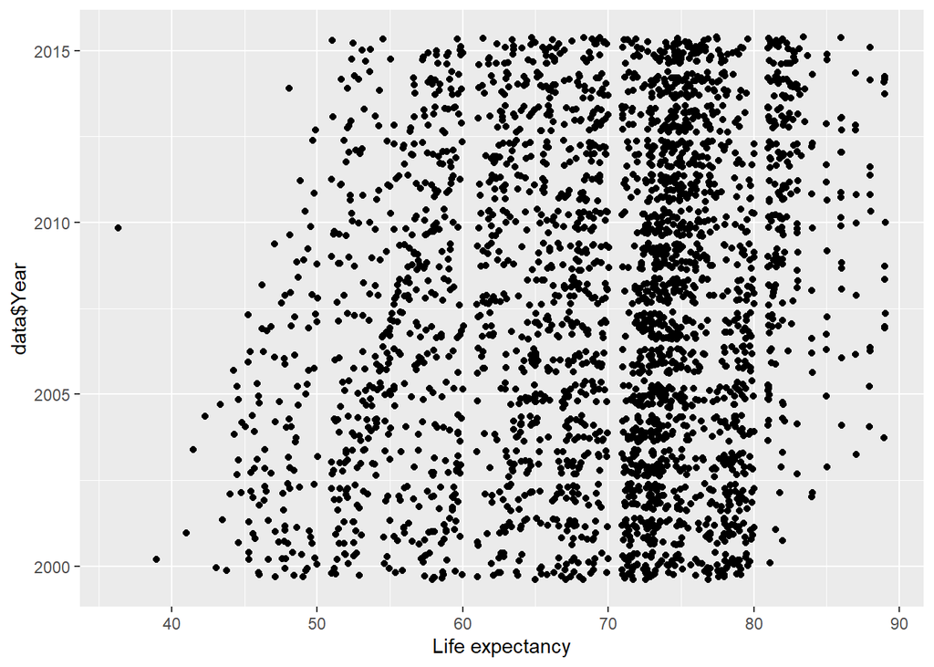

```r
  ylab ('Year')
```

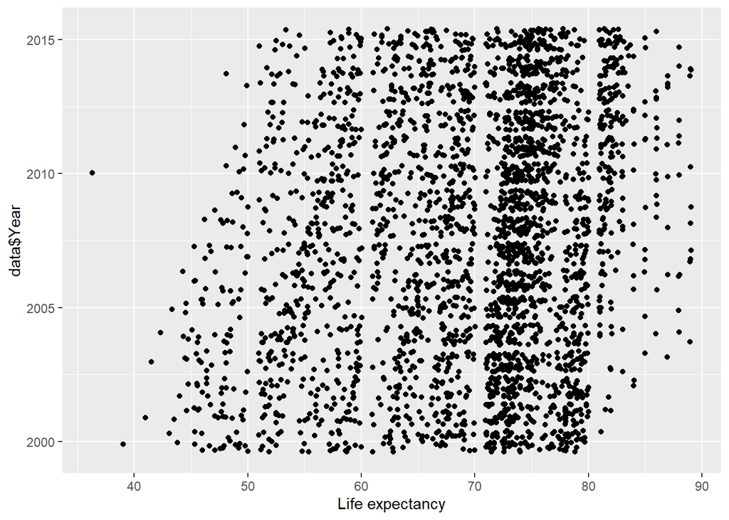

```r
  ylab ('Year')
```

```
## $y
## [1] "Year"
##
## attr(,"class")
## [1] "labels"
```

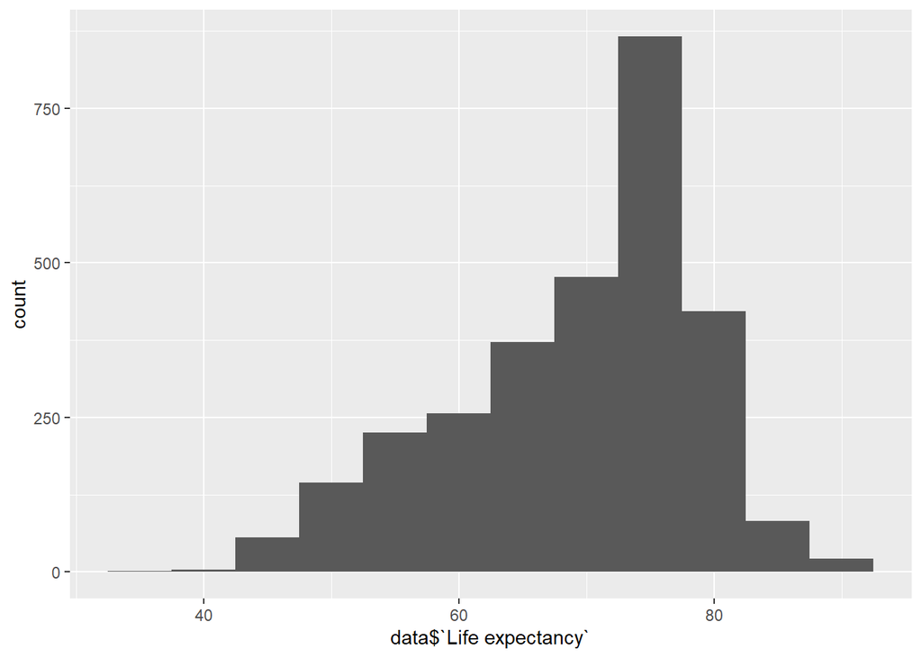

```r
ggplot(data = data,
       mapping = aes(data$`Life expectancy`)) +
  geom_histogram(binwidth = 5)
```

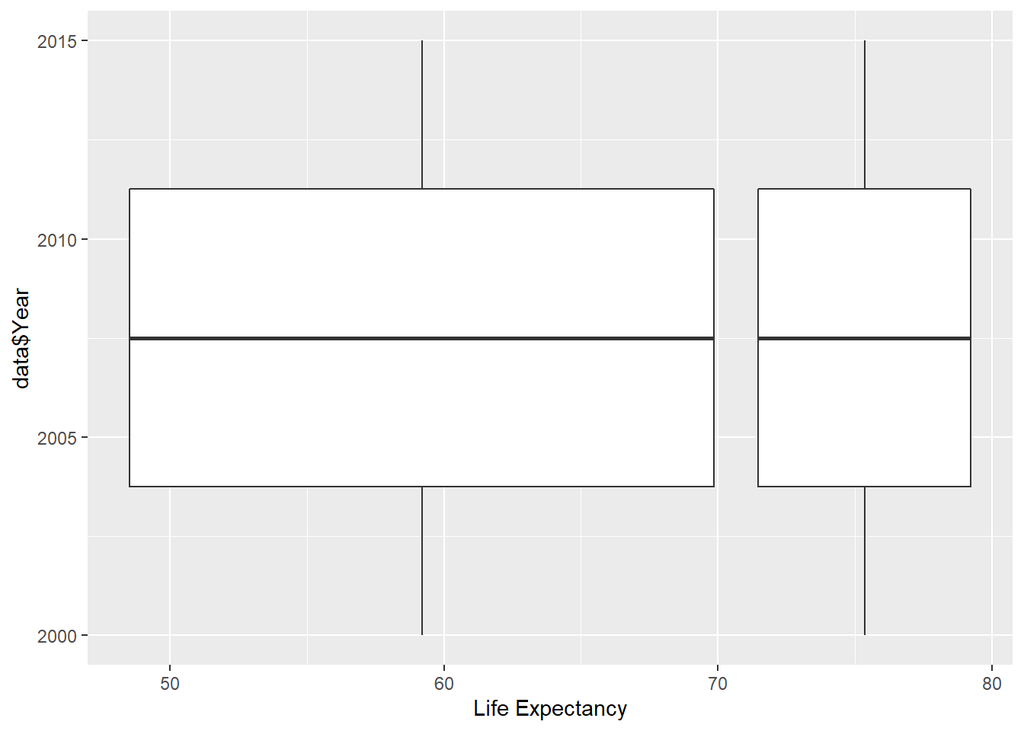

```r
ggplot(data = data,
       mapping = aes(group=data$Status,
                     x=data$`Life expectancy`,
                     y=data$Year)) +
  geom_boxplot() +
  xlab ('Life Expectancy')
```

```r
  ylab ('Year')
```

```
## $y
## [1] "Year"
##
## attr(,"class")
## [1] "labels"
```

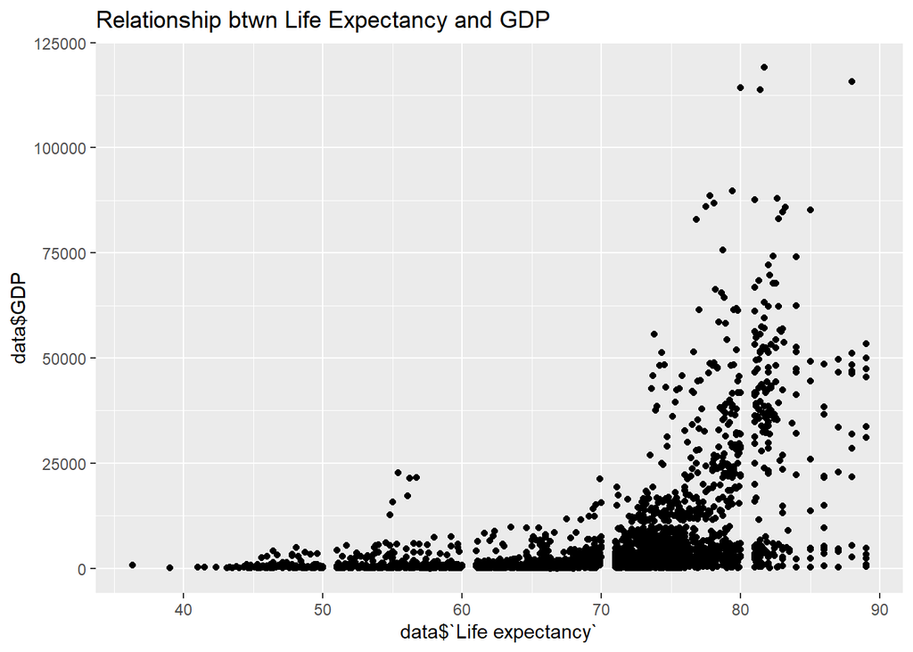

```r
ggplot(data = data,
       aes(x = data$`Life expectancy`, y =data$GDP)) +
  geom_point() + ggtitle("Relationship btwn Life Expectancy and GDP")
```

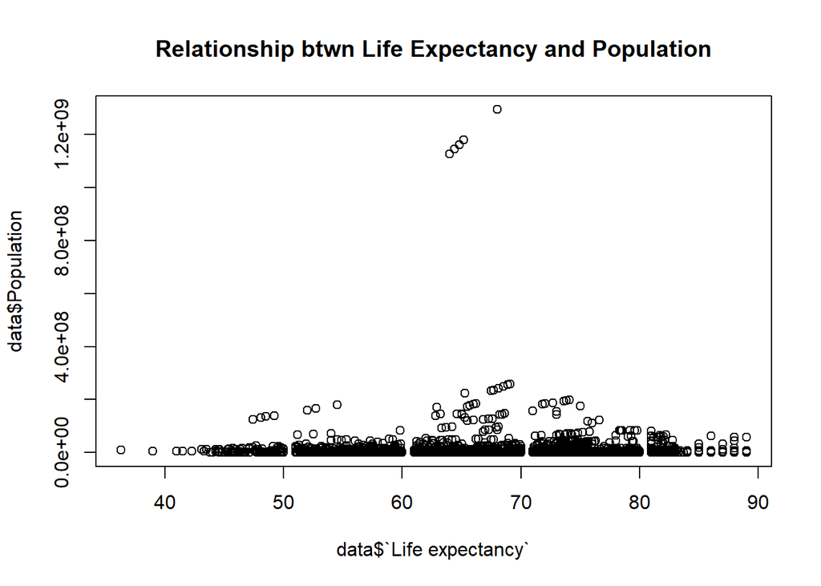

```r
plot(data$`Life expectancy`, data$Population, main="Relationship btwn Life Expectancy and Population")
```

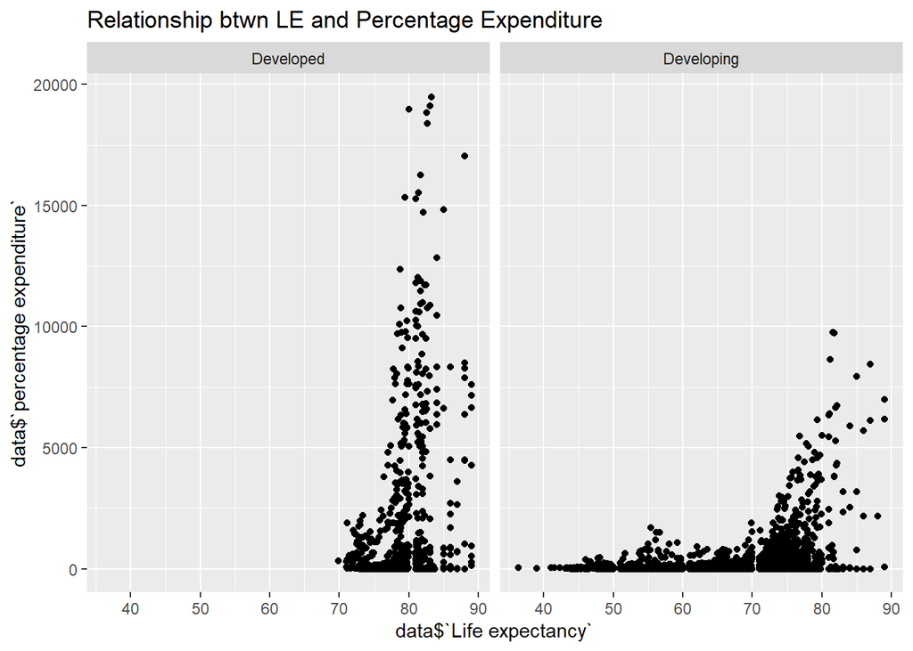

```r
ggplot(data = data,
       aes(x=data$`Life expectancy`,
           y=data$`percentage expenditure`)) +
  geom_point()+ggtitle("Relationship btwn LE and Percentage Expenditure") +facet_grid(.~data$Status)
```

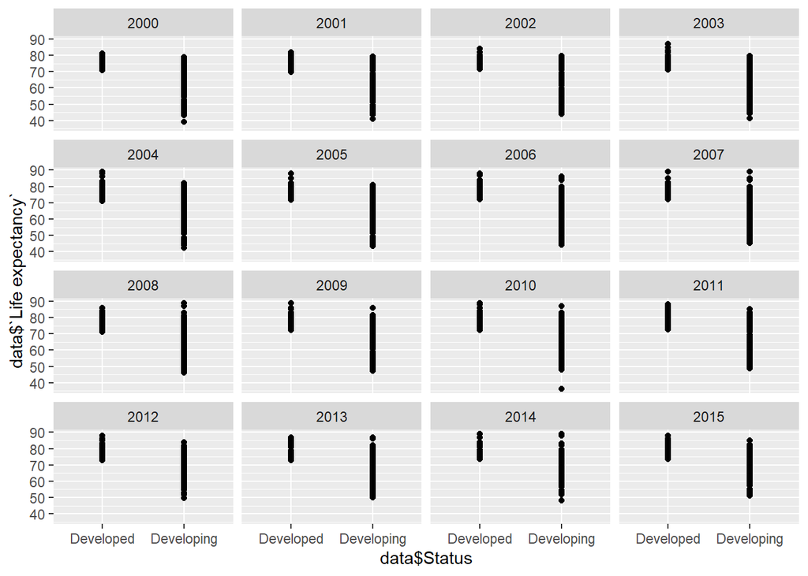

```r
ggplot(data = data,
       mapping = aes(x = data$Status,
                     y = data$`Life expectancy`)) +
  geom_point() +
  facet_wrap(~ data$Year)
```

```r
boxplot(formula = data$`Life expectancy` ~ data$Year, data = data)
```

[figure not shown]

```r
data$Over65 <- data$`Life expectancy` > 65
```

```r
# data$category <- "med"
# data$category [data$`Life expectancy`< LifeExpectancy_low] <- "Low"
# data$category [data$`Life expectancy`< LifeExpectancy_high] <- "High"
```

```r
# LifeExpectancy_low <-quantile(data$`Life expectancy`, probs = c(1/3, 2/3), na.rm = TRUE)[1]
# LifeExpectancy_high <-quantile(data$`Life expectancy`, probs = c(1/3, 2/3), na.rm = TRUE)[2]
```

1. What attributes are there in your data set?
- Some attributes we found were based on Country economics-> GDP, Status, Total Expenditure, and Population demographics-> BMI, mortality, disease, and schooling.
2. Do you have highly correlated attributes? How did you find out about the correlations or lack of correlations?

+We found that High GDP correlates to higher Life Expectancy Rates. The same goes for higher percentage of expenditure.

We found this through the graphs:

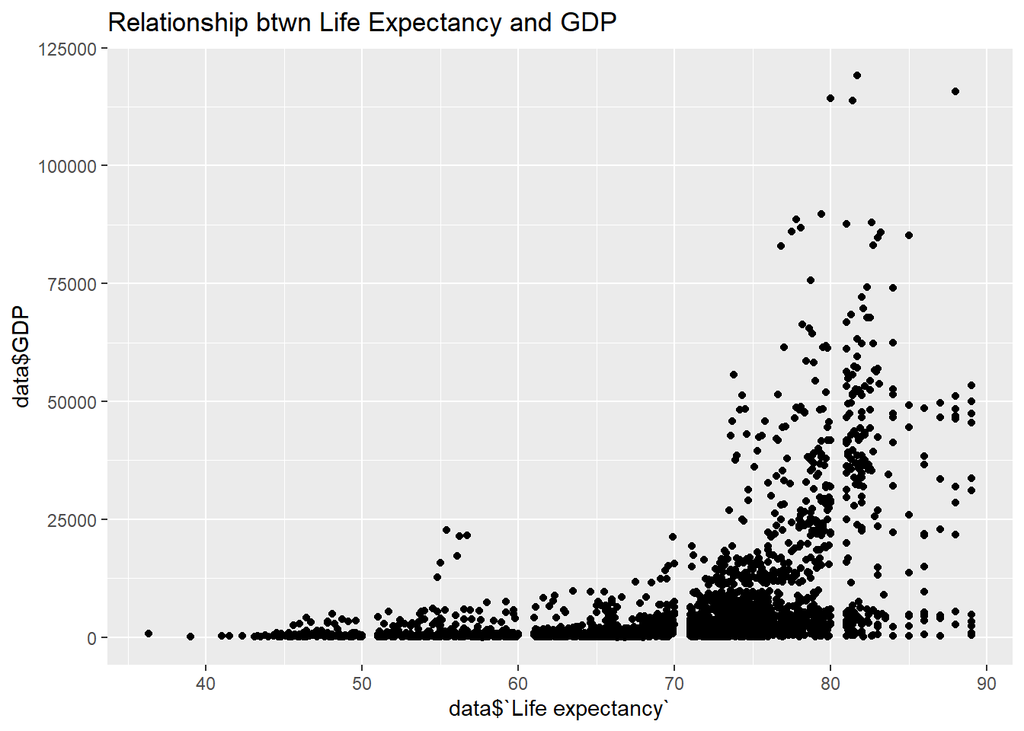

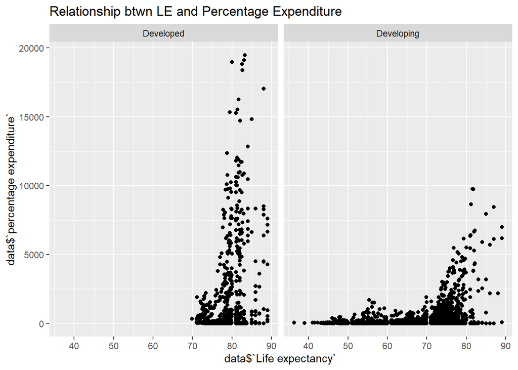

and the status of the country (Developing/Developed) shows that more developed states have a higher mean of Life Expectancy.

```r
aggregate(data$`Life expectancy`, list(data$Status), mean, na.rm=TRUE)
```

```
##      Group.1        x
## 1  Developed 79.19785
## 2 Developing 67.11147
```

3. Do you have numerical attributes that you might want to discretize? Try at least two methods and compare the differences.
- Life Expectancy can be discretized,

#### Binary classification of Life Expectancy rates over 65

```r
data$Over65 <- data$`Life expectancy` > 65
```

```r
LifeExpectancy_low <-quantile(data$`Life expectancy`, probs = c(1/3, 2/3), na.rm = TRUE)[1]
LifeExpectancy_high <-quantile(data$`Life expectancy`, probs = c(1/3, 2/3), na.rm = TRUE)[2]
```

```r
data$category <- "med"
data$category [data$`Life expectancy`< LifeExpectancy_low] <- "Low"
data$category [data$`Life expectancy`< LifeExpectancy_high] <- "High"
```

4.If you have categorical attributes, use the concept hierarchy generation heuristics (based on attribute value counts) suggested in the textbook to produce some concept hierarchies. How well is this approach work for your attributes?

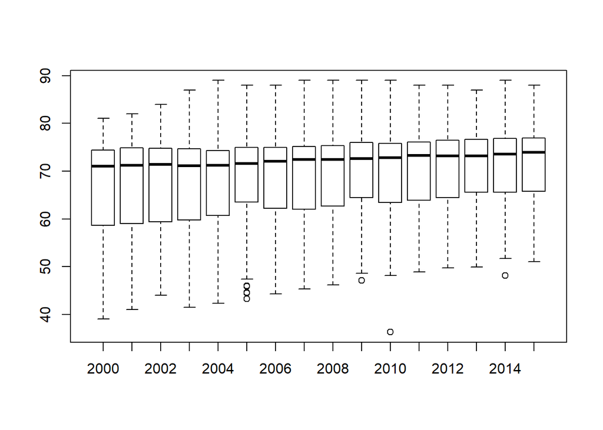